# Organize yourself in RStudio

Author

Silvie Cinková

Published

July 18, 2025

## 1 Jupyter hub at our department’s server

- Work in your web browser, URL below.
- Use your individual user name and password.

[figure not shown]

Figure 1: Login to Jupyterlab

AIC is the name of the server. UFAL is the name of our department. MFF stands for faculty. CUNI.CZ stands for Charles university in Czechia. JLAB is the name of this service.

## 2 Select RStudio

[figure not shown]

Figure 2: Select RStudio

If you want to have it locally, install it from RStudio’s web https://posit.co/products/open-source/rstudio/?sid=1. It will tell you to download and install the bare R first, from the *Comprehensive R Archive Network* https://cran.r-project.org/ .

## 3 Files in RStudio

[figure not shown]

In the top `Menu`, `Select File` > `New`. You will get a choice from a number of formats. I write this with the Quarto tool and choose `Quarto presentation`. Another option is `Quarto document`. It is no big deal which you choose. Both are plain text files.

## 4 Quarto Editor Options: Visual

- many formatting options as buttons
- document displays as a rich text, even with images inserted.

[figure not shown]

Figure 3: Quarto with the visual editor

## 5 Quarto Editor Options: Source

- Displays strictly plain text
- You must format everything manually.

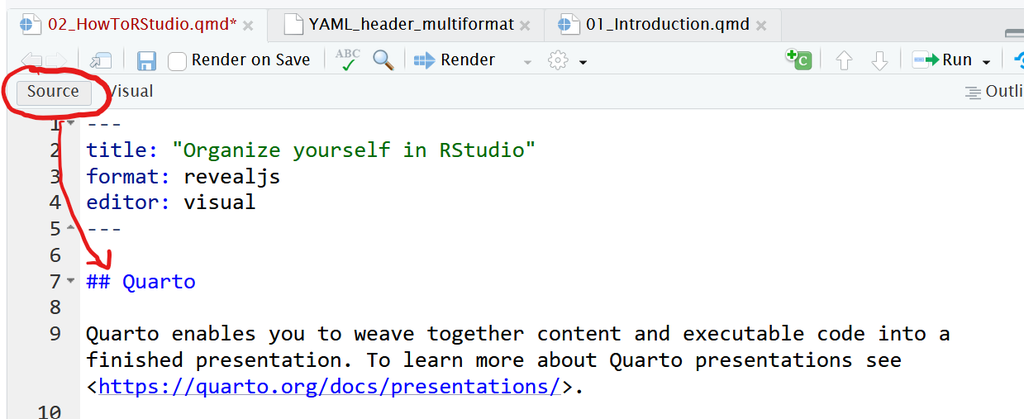

Figure 4: Quarto editor in the source mode

The basic formatting is done with **markdown** tags. You see a Level-2 Heading made with `##` and space and a URL link. For the fastest reference, go to RStudio’s Menu bar and hit `Help > Markdown Quick Reference`. Look to the right bottom pane of RStudio. There are tabs `Files`, `Plots`, `Packages`, `Help`, `Viewer`, and `Presentation`. You will see the `Markdown Quick Reference` in the `Help` tab. But the little markdown you need you can absorb by reading the `.qmd` file of this document with the Source view on.

## 6 YAML header

- File `YAML_header_multiformat`
- Copy-paste it into your new file to get the same formatting you see here.
- Keep files `atrium.css` and `atrium.tex` in the same folder!!!

```
---
title: "Organize yourself in RStudio"
echo: true
format:
  revealjs:
    notes: true
    css: atrium.css
  pdf:
    include-in-header: atrium.tex
  html:
    css: atrium.css
---
```

What makes plain text files real Quarto files is a piece of plain text metadata in the beginning: the YAML header, which you can overwrite.

YAML is not part of R and you will be perfectly fine without it in this course. Here are easy-to-read references to YAML, should you really crave for more:

- https://livingdevops.com/devops/a-complete-non-boring-guide-to-learn-yaml-in-2025/
- https://github.com/VLabStudio/Tutorials/blob/master/The%20Basics%20of%20YAML%20in%20Under%205%20Minutes/Introduction%20to%20YAML.pdf

Quarto has introduced a set of attributes and values in YAML. Here you see some of them. Some attributes explained:

- `echo: true` When you render the document (i.e. typeset the document for printing), also display executable code snippets.
- `format: revealjs, pdf, html` (watch out for the indentation!): you can render it in these three formats. `revealjs` are dynamic html slides as you see them in this presentation. Each format is specified with more fine-grained attributes. We are not going to delve into this. You can read the Quarto user guide and experiment yourself to become an expert.

## 7 CSS file

- Format template for HTML pages, not R-specific.
- Main purpose of `atrium.css`: larger font in code snippets
- No `atrium.css/.tex` in YAML header ⟾ Quarto default

  My YAML header contains references to styling files for html (`atrium.css`) and LaTeX (`atrium.tex`), mainly to make code snippets more legible on slides and to prevent code spilling over the margin in LaTeX (PDF).

  Generally, you should do fine without `.css` and `.tex` files like this, because the Quarto defaults are reasonable.

## 8 Understand note taking with these teaching materials

- *Render* your source `.qmd` files to PDF, HTML, MS Word
- https://quarto.org/docs/presentations/revealjs/

[figure not shown]

Figure 5: The `Render` button produces the document in the format you have specified in the YAML header as `format`.

[figure not shown]

Figure 6: When your YAML header lists multiple output formats, you have to choose which you want to render.

`.qmd` is not very pretty for sharing. You should render it for print or web. Available document formats are PDF, HTML, and MS Word. The last one is not going to work here on the cloud because it needs MS Word locally installed and AIC Jupyterlab is a Linux machine.

Another option is rendering it as `revealjs` slides. revealjs is a Java format based on HTML. It creates dynamic presentations that open in the web browser. It is a different file from the HTML file you get when you render qmd as HTML. In fact, you have to render it live from the source every time you want to run the slide show.

The `revealjs` slide show enables speaker view, export to pdf, and many other widgets, if you list them in the YAML header. Render one of my source files as a slide show and explore it. And here is the user guide for `revealjs` Quarto presentations: https://quarto.org/docs/presentations/revealjs/ .

Find Settings, hit `e` as `Export to PDF mode` and you will get all slides (without speakers notes). Then find `Print` in the browser menu and send it to a printer or to PDF to get a PDF file. Anyway, if you want all this accompanying text along, then you are better off rendering this directly as PDF.

## 9 Resume broken connection

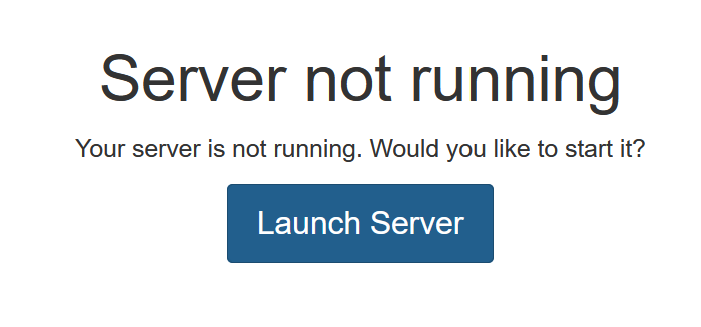

Figure 7: You can see this after login or being idle. Just launch the server.

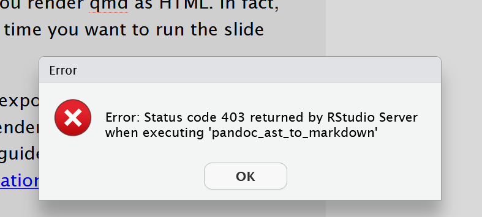

Figure 8: When connection gets interrupted, you will see this. Just refresh and relaunch the server.

When the connection is broken, you will not be able to save or edit your files. Hit `Refresh` in your browser to invoke this page and relaunch the server.

## 10 Control RStudio’s behavior

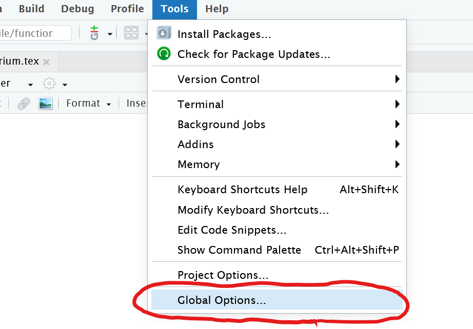

Figure 9: Saving, Encoding, Working directory, Line wrapping...

## 11 Check autosaving options

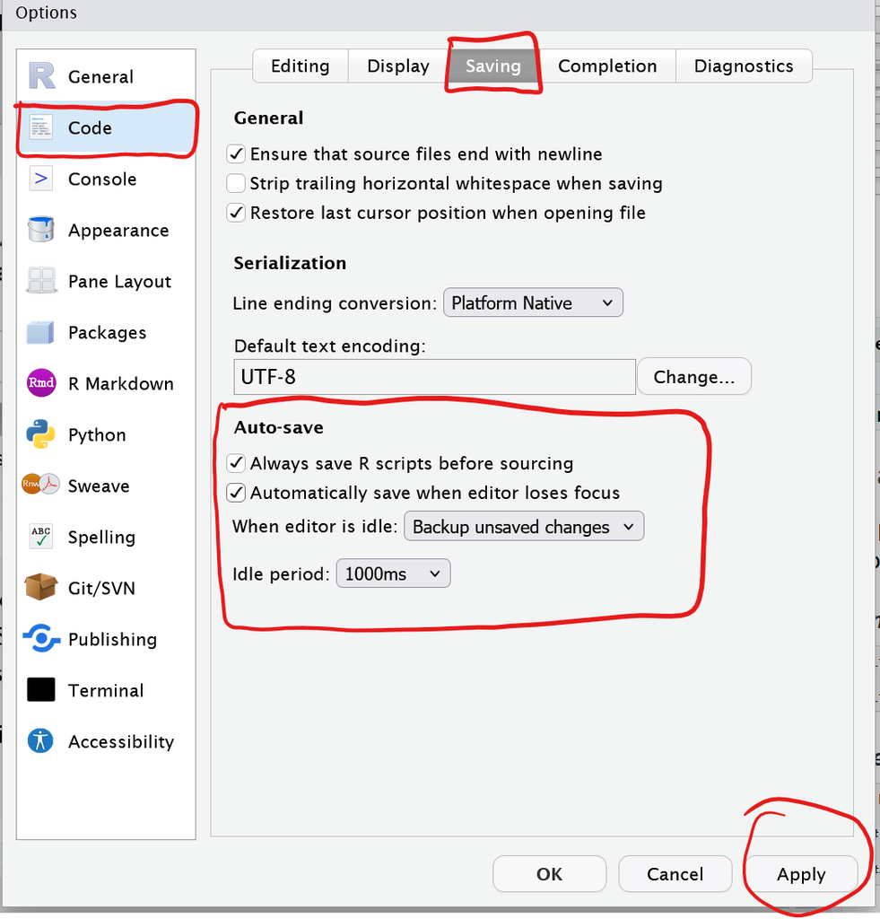

Figure 10: Some reasonable options for autosaving.

## 12 Control character encoding

[figure not shown]

Figure 11: UTF-8 fits most use cases.

## 13 Soft-wrap code

You will be able to see the entire line even if you narrow your browser window.

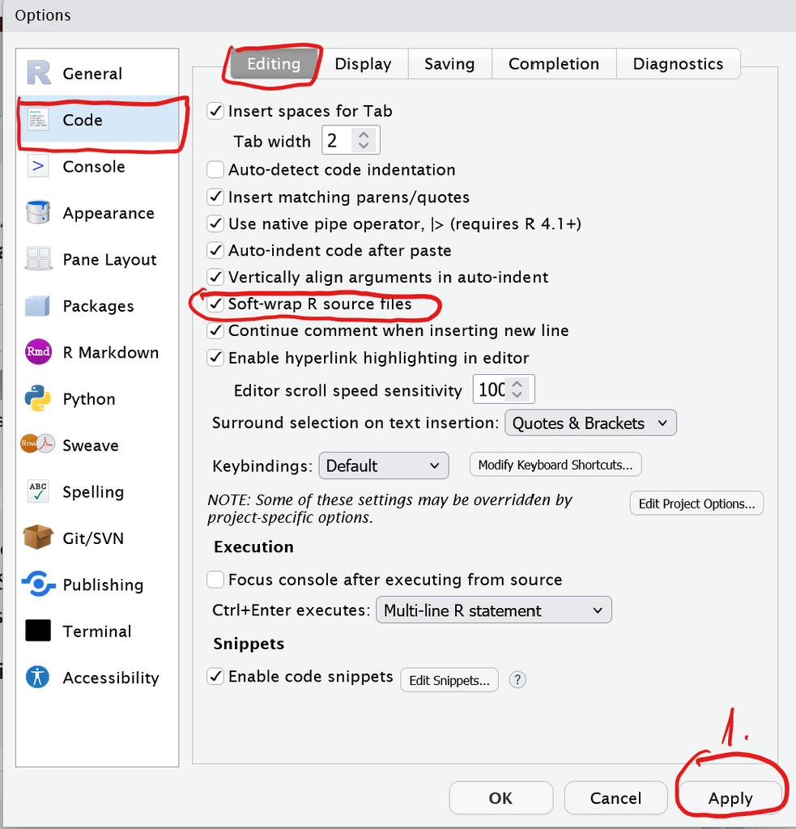

Figure 12: Control code softwrapping

## 14 Control text in `.qmd/.Rmd` documents

- Soft-wrap text lines.
- Display inserted figures in the editor (before rendering).

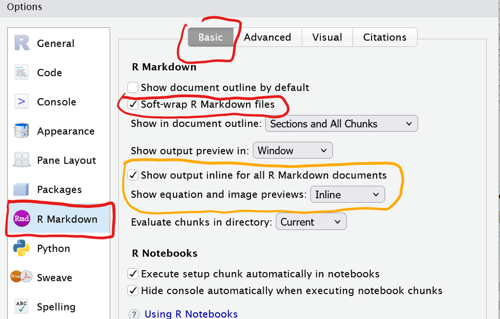

Figure 13: For `.qmd/.Rmd` documents, you have to adjust some options in a separate menu.